# Age of the Congress representative

### Using proportion of US population for each age groups over time dataset and aging congress dataset: Combined the two plots to find out the relationship between age of population and age of congress representative

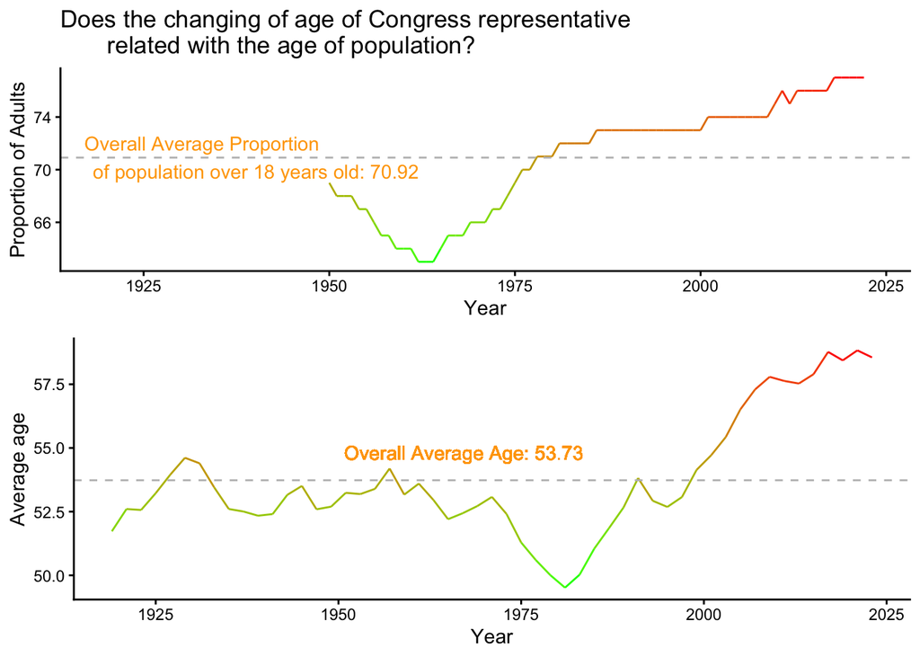

```r
grid.arrange(year_pop_graph, year_age_graph, ncol= 1)
```

The top graph, the y-axis represents the proportion of Adults in USA (age over 18). The bottom graph, the y-axis represents the average age of congress representative. The x-axis for both graphs is the year from 1919 to 2023. Both of the graphs has a similar trend but the deep is in a different year. By comparing of these two graphs, there is a similar trend of increase after the year 2000. In 2000, the proportion of adults in USA is increasing and the average age of the congress representative is increasing also. The age of the population has some kind of relationship with the aging of congress representative after 2000. With a larger adults age group in the USA, the age of the congress representative is increasing.

### USA State Map Data

```r
states <- map_data("state")
states <- states |>
  rename(State = region)
states <- states |>
  select(-subregion)
```

### Using Congress age data and State label Data

```r
joined_data <- left_join(congress, state_names,
                         by = c("state_abbrev" = "Abbreviation"))

joined_data <- joined_data |>
  mutate(State = tolower(State)) |>
  filter(!(state_abbrev %in% c("HI", "AK")))

congress_with_map_data <- left_join(states, joined_data, by = "State") |>
  select(long, lat, age_years, State, state_abbrev) |>
  group_by(State = as.factor(State),
           state_abbrev = as.factor(state_abbrev)) |>
  summarise(long = mean(long),
            lat = mean(lat),
            Avg_age = mean(age_years, na.rm = TRUE)) |>
  filter(!is.na(Avg_age))
# There is a missing value for district of columbia. I choose to remove it.
```

#### Bar Chart: To show the average age of congress representative from each states. The height of the bar can easily oberved the difference.

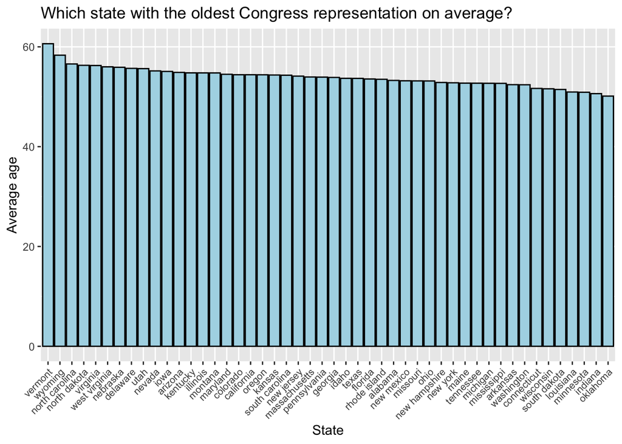

```r
ggplot(congress_with_map_data, aes(x = reorder(State,-Avg_age), y = Avg_age)) +
  geom_bar(stat = "identity", fill = "lightblue", color = "black") +
  theme(axis.text.x = element_text(size = 8, angle = 45, hjust = 1)) +
  labs(x = "State", y = "Average age",
       title = "Which state with the oldest Congress representation on average?")
```

From the bar chart, average age of the congress representative for the state Vermont is the older than others and Wyoming state is the second one.

#### Main USA Map with Average Age of Congress Representative for each states: Using the map to show the location of the states and visual the age of Congress Representative for each states.

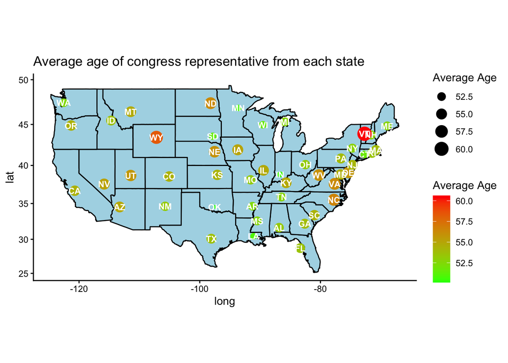

```r
state_labels <- congress_with_map_data %>%
   group_by(state_abbrev) %>%
   summarise(
      long = median(long),
      lat = median(lat)
   )

ggplot() +
  geom_polygon(data = states, aes(x = long, y = lat, group = group),
  fill = "lightblue", color = "black") +
    geom_point(data = congress_with_map_data,
               aes(x = long, y = lat,
                   size = Avg_age,
                   color = Avg_age)) +
  geom_text(data = state_labels,
            aes(x = long, y = lat,
                label = state_abbrev,
                fontface = "bold"),
                size = 3, color = "white") +
  scale_color_gradient(name = "Average Age",
                       low = "green", high = "red") +
  labs(title = "Average age of congress representative from each state",
       size = "Average Age",
       color = "Average Age") +
  coord_map() +
  theme_classic()
```

The dots with closer to red color and larger size represent older average age. We can see the dots for Vermont and Wyoming state are the larger and closer to red than the others state.